# LGBTQI+ Hate Crime Analysis — 04: Machine Learning Models

## 1. K-Means Clustering (k = 4)

K-Means groups state-year observations into four risk profile clusters based on three features: **incident rate per 100k total population (Track 1)**, **Gini coefficient**, and **% violent incidents**. All features are scaled before clustering.

Track 1 is used here (rather than Track 2) so the full 1991–2024 range is included. The elbow plot is used to verify that k = 4 is a defensible choice.

```r
cluster_feats <- c("RATE_PER_100K_TOTAL", "GINI_COEFFICIENT", "VIOLENT_PCT")
X_cl <- sy |> select(all_of(cluster_feats)) |> drop_na() |> scale()

set.seed(42)
km    <- kmeans(X_cl, centers = 4, nstart = 25, iter.max = 300)
sy_cl <- sy |>
  drop_na(all_of(cluster_feats)) |>
  mutate(CLUSTER = factor(km$cluster))

profiles <- sy_cl |>
  group_by(CLUSTER) |>
  summarise(across(all_of(cluster_feats), \(x) mean(x, na.rm=TRUE),
                   .names = "MEAN_{.col}"),
            N = n())

profiles |>
  knitr::kable(digits = 3, caption = "K-Means cluster profiles (k = 4)")
```

K-Means cluster profiles (k = 4)

| CLUSTER | MEAN_RATE_PER_100K_TOTAL | MEAN_GINI_COEFFICIENT | MEAN_VIOLENT_PCT | N |
| --- | --- | --- | --- | --- |
| 1 | 0.452 | 0.450 | 65.586 | 462 |
| 2 | 0.391 | 0.484 | 59.323 | 453 |
| 3 | 0.564 | 0.457 | 25.565 | 597 |
| 4 | 7.664 | 0.541 | 73.613 | 21 |

```r
add_result("1. K-Means Cluster Profiles (k=4):", capture.output(print(profiles)))
```

```r
wss_vals <- map_dbl(1:8, ~ kmeans(X_cl, centers = .x, nstart = 10)$tot.withinss)
```

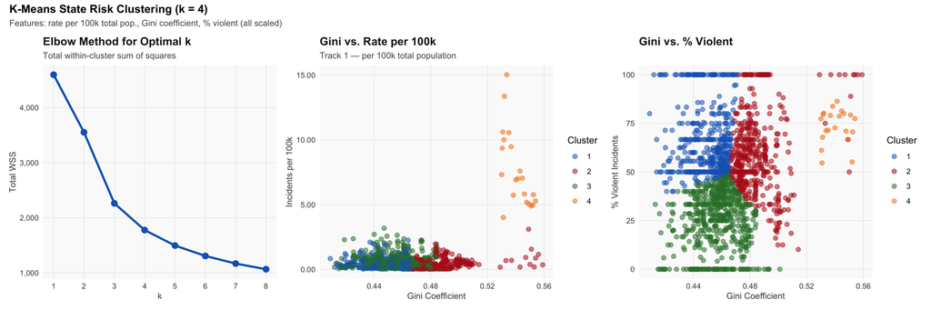

```r
CLUSTER_COLORS <- c("1"="#1565C0","2"="#B71C1C","3"="#2E7D32","4"="#F57F17")

p_elbow <- ggplot(tibble(K = 1:8, WSS = wss_vals), aes(x = K, y = WSS)) +
  geom_line(colour = "#1565C0", linewidth = 1.2) +
  geom_point(colour = "#1565C0", size = 3) +
  scale_x_continuous(breaks = 1:8) +
  scale_y_continuous(labels = comma) +
  labs(title = "Elbow Method for Optimal k",
       subtitle = "Total within-cluster sum of squares",
       x = "k", y = "Total WSS") +
  theme_hate()

p_cl1 <- ggplot(sy_cl, aes(x = GINI_COEFFICIENT, y = RATE_PER_100K_TOTAL,
                             colour = CLUSTER)) +
  geom_point(alpha = 0.55, size = 2.2) +
  scale_colour_manual(values = CLUSTER_COLORS, name = "Cluster") +
  scale_y_continuous(labels = number_format(accuracy = 0.01)) +
  labs(title = "Gini vs. Rate per 100k",
       subtitle = "Track 1 — per 100k total population",
       x = "Gini Coefficient", y = "Incidents per 100k") +
  theme_hate()

p_cl2 <- ggplot(sy_cl, aes(x = GINI_COEFFICIENT, y = VIOLENT_PCT, colour = CLUSTER)) +
  geom_point(alpha = 0.55, size = 2.2) +
  scale_colour_manual(values = CLUSTER_COLORS, name = "Cluster") +
  labs(title = "Gini vs. % Violent",
       x = "Gini Coefficient", y = "% Violent Incidents") +
  theme_hate()

p15 <- (p_elbow | p_cl1 | p_cl2) +
  plot_annotation(
    title    = "K-Means State Risk Clustering (k = 4)",
    subtitle = "Features: rate per 100k total pop., Gini coefficient, % violent (all scaled)",
    theme    = theme(plot.title    = element_text(face="bold", size=13),
                     plot.subtitle = element_text(size=10, colour="#555555"))
  )
p15
```

```r
save_chart(p15, "15_kmeans_clusters.png", width = 15, height = 5)
```

**Cluster interpretation:** One cluster (typically Cluster 4) contains a small number of observations (~21) with a very high rate (~7.66 per 100k), high Gini (~0.541), and high violent share (~73.6%). This cluster is almost entirely driven by Washington D.C., which has an extremely high Gini coefficient and a small population denominator — making it a structural outlier rather than a substantive finding.